# **Used Cars Price Prediction**

## **Problem Definition**

### **The Context:**

There is a huge demand for used cars in the Indian Market today. As sales of new cars have slowed down in the recent past, the pre-owned car market has continued to grow over the past few years and is now larger than the new car market. Cars4U is a budding tech start-up that aims to find footholes in this market.

In 2018-19, while new car sales were recorded at 3.6 million units, around 4 million second-hand cars were bought and sold. There is a slowdown in new car sales and that could mean that the demand is shifting towards the pre-owned market. In fact, some car owners replace their old vehicles with pre-owned cars instead of buying a new automobile.

Unlike new cars, where price and supply are fairly deterministic and managed by OEMs (Original Equipment Manufacturer / except for dealership level discounts which come into play only in the last stage of the customer journey), the used car market is a very different beast, with large uncertainties in both pricing and supply. Several factors, including mileage, brand, model, year, etc. can influence the actual worth of a car. From the perspective of a seller, it is not an easy task to set the correct price of a used car. Keeping this in mind, the pricing scheme of these used cars becomes important in order to grow in the market.

### **The objective:**

Come up with a pricing model that can effectively predict the price of used cars and can help the business in devising protable strategies using differential pricing.

### **The key questions:**

What are the main variables that impact the price of the car? What are the relationships between these variables? Which is the best model for this problem?

### **The problem formulation**:

How can we accurately calculate and set the price of used cars?

### **Data Dictionary**

**S.No.** : Serial Number

**Name** : Name of the car which includes Brand name and Model name

**Location** : The location in which the car is being sold or is available for purchase (Cities)

**Year** : Manufacturing year of the car

**Kilometers_driven** : The total kilometers driven in the car by the previous owner(s) in KM

**Fuel_Type** : The type of fuel used by the car (Petrol, Diesel, Electric, CNG, LPG)

**Transmission** : The type of transmission used by the car (Automatic / Manual)

**Owner** : Type of ownership

**Mileage** : The standard mileage offered by the car company in kmpl or km/kg

**Engine** : The displacement volume of the engine in CC

**Power** : The maximum power of the engine in bhp

**Seats** : The number of seats in the car

**New_Price** : The price of a new car of the same model in INR 100,000

**Price** : The price of the used car in INR 100,000 (**Target Variable**)

### **Loading libraries**

```python
# import libraries for data manipulation
import numpy as np
import pandas as pd

# import libraries for data visualization
import matplotlib.pyplot as plt
import seaborn as sns

# import libraries for linear regression model
from statsmodels.formula.api import ols
import statsmodels.api as sm
from sklearn.linear_model import LinearRegression
from sklearn import metrics
from sklearn.metrics import mean_squared_error
from sklearn.metrics import accuracy_score

# import library for preparing data
from sklearn.model_selection import train_test_split

# To ignore warnings
import warnings
warnings.filterwarnings('ignore')

# Remove the limit from the number of displayed columns and rows. It helps to see the entire dataframe while printing it
pd.set_option("display.max_columns", None)
```

### **Let us load the data**

```python
df = pd.read_csv('used_cars.csv')
```

## Data Overview

- Observations
- Sanity checks

```python
#observations
df.head()
```

|  | S.No. | Name | Location | Year | Kilometers_Driven | Fuel_Type | Transmission | Owner_Type | Mileage | Engine | Power | Seats | New_price | Price |
| --- | --- | --- | --- | --- | --- | --- | --- | --- | --- | --- | --- | --- | --- | --- |
| 0 | 0 | Maruti Wagon R LXI CNG | Mumbai | 2010 | 72000 | CNG | Manual | First | 26.60 | 998.0 | 58.16 | 5.0 | NaN | 1.75 |
| 1 | 1 | Hyundai Creta 1.6 CRDi SX Option | Pune | 2015 | 41000 | Diesel | Manual | First | 19.67 | 1582.0 | 126.20 | 5.0 | NaN | 12.50 |
| 2 | 2 | Honda Jazz V | Chennai | 2011 | 46000 | Petrol | Manual | First | 18.20 | 1199.0 | 88.70 | 5.0 | 8.61 | 4.50 |
| 3 | 3 | Maruti Ertiga VDI | Chennai | 2012 | 87000 | Diesel | Manual | First | 20.77 | 1248.0 | 88.76 | 7.0 | NaN | 6.00 |
| 4 | 4 | Audi A4 New 2.0 TDI Multitronic | Coimbatore | 2013 | 40670 | Diesel | Automatic | Second | 15.20 | 1968.0 | 140.80 | 5.0 | NaN | 17.74 |

```python
#sanity check
df.shape
```

```
(7253, 14)
```

```python
#observations
df.info()
```

```
<class 'pandas.core.frame.DataFrame'>
RangeIndex: 7253 entries, 0 to 7252
Data columns (total 14 columns):
 #   Column             Non-Null Count  Dtype
---  ------             --------------  -----
 0   S.No.              7253 non-null   int64
 1   Name               7253 non-null   object
 2   Location           7253 non-null   object
 3   Year               7253 non-null   int64
 4   Kilometers_Driven  7253 non-null   int64
 5   Fuel_Type          7253 non-null   object
 6   Transmission       7253 non-null   object
 7   Owner_Type         7253 non-null   object
 8   Mileage            7251 non-null   float64
 9   Engine             7207 non-null   float64
 10  Power              7078 non-null   float64
 11  Seats              7200 non-null   float64
 12  New_price          1006 non-null   float64
 13  Price              6019 non-null   float64
dtypes: float64(6), int64(3), object(5)
memory usage: 793.4+ KB
```

```python
#sanity check - check for # of null values for each column
len(df.index)-df.count()
```

```
S.No.                   0
Name                    0
Location                0
Year                    0
Kilometers_Driven       0
Fuel_Type               0
Transmission            0
Owner_Type              0
Mileage                 2
Engine                 46
Power                 175
Seats                  53
New_price            6247
Price                1234
dtype: int64
```

```python
#sanity check
df.duplicated().sum()
```

```
0
```

## Observations & Sanity Check Notes

- There are missing values in columns 8-13
- The New_price column has too many nulls, making it unreliable and will need to be removed
- Other rows with missing values will also need to be imputed or removed
- There are no duplicates

## **Exploratory Data Analysis**

- EDA is an important part of any project involving data.
- It is important to investigate and understand the data better before building a model with it.
- A few questions have been mentioned below which will help you approach the analysis in the right manner and generate insights from the data.
- A thorough analysis of the data, in addition to the questions mentioned below, should be done.

**Questions:**

1. What is the summary statistics of the data? Explore summary statistics for numerical variables and the categorical variables
2. Find out number of unique observations in each category of categorical columns? Write your findings/observations/insights
3. Check the extreme values in different columns of the given data and write down the observtions? Remove the data where the values are un-realistic

```python
#What is the summary statistics of the data?
#Explore summary statistics for numerical variables and the categorical variables
#summary statistics of data for numerical variables
df.describe().T
```

|  | count | mean | std | min | 25% | 50% | 75% | max |
| --- | --- | --- | --- | --- | --- | --- | --- | --- |
| S.No. | 7253.0 | 3626.000000 | 2093.905084 | 0.00 | 1813.000 | 3626.00 | 5439.0000 | 7252.00 |
| Year | 7253.0 | 2013.365366 | 3.254421 | 1996.00 | 2011.000 | 2014.00 | 2016.0000 | 2019.00 |
| Kilometers_Driven | 7253.0 | 58699.063146 | 84427.720583 | 171.00 | 34000.000 | 53416.00 | 73000.0000 | 6500000.00 |
| Mileage | 7251.0 | 18.141580 | 4.562197 | 0.00 | 15.170 | 18.16 | 21.1000 | 33.54 |
| Engine | 7207.0 | 1616.573470 | 595.285137 | 72.00 | 1198.000 | 1493.00 | 1968.0000 | 5998.00 |
| Power | 7078.0 | 112.765214 | 53.493553 | 34.20 | 75.000 | 94.00 | 138.1000 | 616.00 |
| Seats | 7200.0 | 5.280417 | 0.809277 | 2.00 | 5.000 | 5.00 | 5.0000 | 10.00 |
| New_price | 1006.0 | 22.779692 | 27.759344 | 3.91 | 7.885 | 11.57 | 26.0425 | 375.00 |
| Price | 6019.0 | 9.479468 | 11.187917 | 0.44 | 3.500 | 5.64 | 9.9500 | 160.00 |

### Observations

```python
#What is the summary statistics of the data?
#Explore summary statistics for numerical variables and the categorical variables
#summary statistics of data for categorical variables

# Make list for categorical variables
cat_vars = ["Name", "Location", "Fuel_Type", "Transmission", "Owner_Type", "Year", "Seats"]

# Print count of unique value in each column
for column in cat_vars:
    print(df[column].value_counts())
    print("-" * 50)
```

```
Name
Mahindra XUV500 W8 2WD                  55
Maruti Swift VDI                        49
Maruti Swift Dzire VDI                  42
Honda City 1.5 S MT                     39
Maruti Swift VDI BSIV                   37
                                        ..
Chevrolet Beat LT Option                 1
Skoda Rapid 1.6 MPI AT Elegance Plus     1
Ford EcoSport 1.5 TDCi Ambiente          1
Hyundai i10 Magna 1.1 iTech SE           1
Hyundai Elite i20 Magna Plus             1
Name: count, Length: 2041, dtype: int64
--------------------------------------------------
Location
Mumbai        949
Hyderabad     876
Coimbatore    772
Kochi         772
Pune          765
Delhi         660
Kolkata       654
Chennai       591
Jaipur        499
Bangalore     440
Ahmedabad     275
Name: count, dtype: int64
--------------------------------------------------
Fuel_Type
Diesel      3852
Petrol      3325
CNG           62
LPG           12
Electric       2
Name: count, dtype: int64
--------------------------------------------------
Transmission
Manual       5204
Automatic    2049
Name: count, dtype: int64
```

[output cut: 30 more lines]

```
1999      2
1996      1
Name: count, dtype: int64
--------------------------------------------------
Seats
5.0     6048
7.0      796
8.0      170
4.0      119
6.0       38
2.0       18
10.0       8
9.0        3
Name: count, dtype: int64
--------------------------------------------------
```

```python
# Print count by % of unique value in each column
for column in cat_vars:
    print(df[column].value_counts(normalize=True))
    print("-" * 50)
```

```
Name
Mahindra XUV500 W8 2WD                  0.007583
Maruti Swift VDI                        0.006756
Maruti Swift Dzire VDI                  0.005791
Honda City 1.5 S MT                     0.005377
Maruti Swift VDI BSIV                   0.005101
                                          ...
Chevrolet Beat LT Option                0.000138
Skoda Rapid 1.6 MPI AT Elegance Plus    0.000138
Ford EcoSport 1.5 TDCi Ambiente         0.000138
Hyundai i10 Magna 1.1 iTech SE          0.000138
Hyundai Elite i20 Magna Plus            0.000138
Name: proportion, Length: 2041, dtype: float64
--------------------------------------------------
Location
Mumbai        0.130842
Hyderabad     0.120778
Coimbatore    0.106439
Kochi         0.106439
Pune          0.105474
Delhi         0.090997
Kolkata       0.090170
Chennai       0.081484
Jaipur        0.068799
Bangalore     0.060665
Ahmedabad     0.037915
Name: proportion, dtype: float64
--------------------------------------------------
Fuel_Type
Diesel      0.531091
Petrol      0.458431
CNG         0.008548
LPG         0.001654
Electric    0.000276
Name: proportion, dtype: float64
--------------------------------------------------
Transmission
Manual       0.717496
Automatic    0.282504
Name: proportion, dtype: float64
```

[output cut: 30 more lines]

```
1999    0.000276
1996    0.000138
Name: proportion, dtype: float64
--------------------------------------------------
Seats
5.0     0.840000
7.0     0.110556
8.0     0.023611
4.0     0.016528
6.0     0.005278
2.0     0.002500
10.0    0.001111
9.0     0.000417
Name: proportion, dtype: float64
--------------------------------------------------
```

### Observations

```python
df.nunique()
```

```
S.No.                7253
Name                 2041
Location               11
Year                   23
Kilometers_Driven    3660
Fuel_Type               5
Transmission            2
Owner_Type              4
Mileage               438
Engine                150
Power                 383
Seats                   8
New_price             625
Price                1373
dtype: int64
```

### Observations

- There are 7253 unique serial #'s in the dataset
- There are way too many unique values for Name since it's a categorical variable
- I was expecting the numerical variables to have closer to 6k unique values since there are 7k unique cars, so it is interesting that the counts are much lower. These cars seems to share a lot of the same specs.
- There are 23 years which make sense since the years range from 1996 to 2019

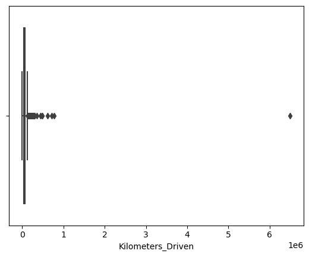

```python
# Checking for extreme values for KM Driven
sns.boxplot(data=df,x='Kilometers_Driven')
plt.show()
```

- The max value of KM Driven is a very unrealistic outlier (6,500,000km)
- This will need to be removed from the data

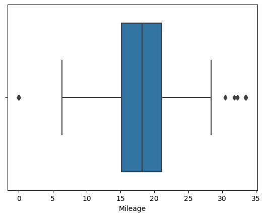

```python
# Checking for extreme values for Mileage
sns.boxplot(data=df,x='Mileage')
plt.show()
```

- Mileage of 0 is unrealistic and will need to be removed or imputed

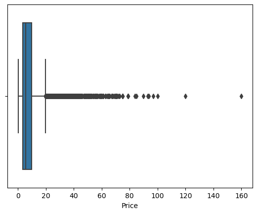

```python
# Checking for extreme values for Price
sns.boxplot(data=df,x='Price')
plt.show()
```

- The max of 16,000,000 INR seemed unrealistic when looking at the summary statistics, but looking at the boxplot and thinking of how expensive cars can be, it could be feasible.

```python
# Checking car info for max price plot
df.iloc[df.Price.idxmax()]
```

```
S.No.                                                       4079
Name                 Land Rover Range Rover 3.0 Diesel LWB Vogue
Location                                               Hyderabad
Year                                                        2017
Kilometers_Driven                                          25000
Fuel_Type                                                 Diesel
Transmission                                           Automatic
Owner_Type                                                 First
Mileage                                                    13.33
Engine                                                    2993.0
Power                                                      255.0
Seats                                                        5.0
New_price                                                  230.0
Price                                                      160.0
Name: 4079, dtype: object
```

- Price seems to be realistic for car brand/model, so I will not be removing outliers for Price

## Removing unrealistic values

```python
# Looking for Record of KM Drive outlier
df.sort_values(by='Kilometers_Driven', ascending=False).head(10)
```

|  | S.No. | Name | Location | Year | Kilometers_Driven | Fuel_Type | Transmission | Owner_Type | Mileage | Engine | Power | Seats | New_price | Price |
| --- | --- | --- | --- | --- | --- | --- | --- | --- | --- | --- | --- | --- | --- | --- |
| 2328 | 2328 | BMW X5 xDrive 30d M Sport | Chennai | 2017 | 6500000 | Diesel | Automatic | First | 15.97 | 2993.0 | 258.00 | 5.0 | NaN | 65.00 |
| 340 | 340 | Skoda Octavia Ambition Plus 2.0 TDI AT | Kolkata | 2013 | 775000 | Diesel | Automatic | First | 19.30 | 1968.0 | 141.00 | 5.0 | NaN | 7.50 |
| 1860 | 1860 | Volkswagen Vento Diesel Highline | Chennai | 2013 | 720000 | Diesel | Manual | First | 20.54 | 1598.0 | 103.60 | 5.0 | NaN | 5.90 |
| 358 | 358 | Hyundai i10 Magna 1.2 | Chennai | 2009 | 620000 | Petrol | Manual | First | 20.36 | 1197.0 | 78.90 | 5.0 | NaN | 2.70 |
| 2823 | 2823 | Volkswagen Jetta 2013-2015 2.0L TDI Highline AT | Chennai | 2015 | 480000 | Diesel | Automatic | First | 16.96 | 1968.0 | 138.03 | 5.0 | NaN | 13.00 |
| 3092 | 3092 | Honda City i VTEC SV | Kolkata | 2015 | 480000 | Petrol | Manual | First | 17.40 | 1497.0 | 117.30 | 5.0 | NaN | 5.00 |
| 4491 | 4491 | Hyundai i20 Magna Optional 1.2 | Bangalore | 2013 | 445000 | Petrol | Manual | First | 18.50 | 1197.0 | 82.90 | 5.0 | NaN | 4.45 |
| 6921 | 6921 | Maruti Swift Dzire Tour LDI | Jaipur | 2012 | 350000 | Diesel | Manual | First | 23.40 | 1248.0 | 74.00 | 5.0 | NaN | NaN |
| 3649 | 3649 | Tata Indigo LS | Jaipur | 2008 | 300000 | Diesel | Manual | First | 17.00 | 1405.0 | 70.00 | 5.0 | NaN | 1.00 |
| 1528 | 1528 | Toyota Innova 2.5 G (Diesel) 8 Seater BS IV | Hyderabad | 2005 | 299322 | Diesel | Manual | First | 12.80 | 2494.0 | 102.00 | 8.0 | NaN | 4.00 |

```python
# Removing 6,500,000km from KM Driven

df.drop([2328], inplace=True)
```

```python
# Checking to make sure it was dropped

df.sort_values(by='Kilometers_Driven', ascending=False).head(10)
```

|  | S.No. | Name | Location | Year | Kilometers_Driven | Fuel_Type | Transmission | Owner_Type | Mileage | Engine | Power | Seats | New_price | Price |
| --- | --- | --- | --- | --- | --- | --- | --- | --- | --- | --- | --- | --- | --- | --- |
| 340 | 340 | Skoda Octavia Ambition Plus 2.0 TDI AT | Kolkata | 2013 | 775000 | Diesel | Automatic | First | 19.30 | 1968.0 | 141.00 | 5.0 | NaN | 7.50 |
| 1860 | 1860 | Volkswagen Vento Diesel Highline | Chennai | 2013 | 720000 | Diesel | Manual | First | 20.54 | 1598.0 | 103.60 | 5.0 | NaN | 5.90 |
| 358 | 358 | Hyundai i10 Magna 1.2 | Chennai | 2009 | 620000 | Petrol | Manual | First | 20.36 | 1197.0 | 78.90 | 5.0 | NaN | 2.70 |
| 2823 | 2823 | Volkswagen Jetta 2013-2015 2.0L TDI Highline AT | Chennai | 2015 | 480000 | Diesel | Automatic | First | 16.96 | 1968.0 | 138.03 | 5.0 | NaN | 13.00 |
| 3092 | 3092 | Honda City i VTEC SV | Kolkata | 2015 | 480000 | Petrol | Manual | First | 17.40 | 1497.0 | 117.30 | 5.0 | NaN | 5.00 |
| 4491 | 4491 | Hyundai i20 Magna Optional 1.2 | Bangalore | 2013 | 445000 | Petrol | Manual | First | 18.50 | 1197.0 | 82.90 | 5.0 | NaN | 4.45 |
| 6921 | 6921 | Maruti Swift Dzire Tour LDI | Jaipur | 2012 | 350000 | Diesel | Manual | First | 23.40 | 1248.0 | 74.00 | 5.0 | NaN | NaN |
| 3649 | 3649 | Tata Indigo LS | Jaipur | 2008 | 300000 | Diesel | Manual | First | 17.00 | 1405.0 | 70.00 | 5.0 | NaN | 1.00 |
| 1528 | 1528 | Toyota Innova 2.5 G (Diesel) 8 Seater BS IV | Hyderabad | 2005 | 299322 | Diesel | Manual | First | 12.80 | 2494.0 | 102.00 | 8.0 | NaN | 4.00 |
| 6919 | 6919 | ISUZU D-MAX V-Cross 4X4 | Jaipur | 2017 | 290000 | Diesel | Manual | First | 12.40 | 2499.0 | 134.00 | 5.0 | NaN | NaN |

## **Univariate Analysis**

**Questions:**

1. Do univariate analysis for numerical and categorical variables?
2. Check the distribution of the different variables? is the distributions skewed?
3. Do we need to do log_transformation, if so for what variables we need to do?
4. Perfoem the log_transformation(if needed) and write down your observations?

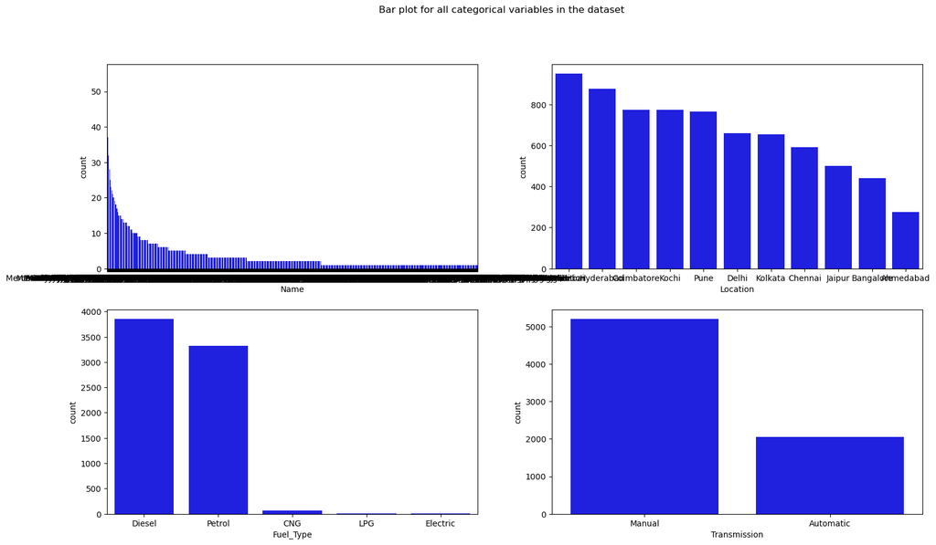

```python
# Univariate analysis for categorical variables

fig, axes = plt.subplots(2,2, figsize = (18, 10))

fig.suptitle('Bar plot for all categorical variables in the dataset')

sns.countplot(ax = axes[0, 0], x = 'Name', data = df, color = 'blue',
              order = df['Name'].value_counts().index);

sns.countplot(ax = axes[0, 1], x = 'Location', data = df, color = 'blue',
              order = df['Location'].value_counts().index);

sns.countplot(ax = axes[1, 0], x = 'Fuel_Type', data = df, color = 'blue',
              order = df['Fuel_Type'].value_counts().index);

sns.countplot(ax = axes[1, 1], x = 'Transmission', data = df, color = 'blue',
              order = df['Transmission'].value_counts().index);
```

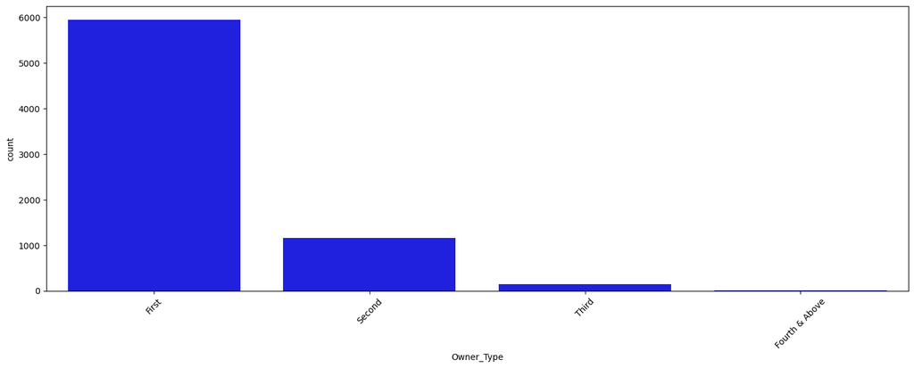

```python
# Univariate analysis for Owner Type

fig = plt.figure(figsize = (18, 6))

sns.countplot(x = 'Owner_Type', data = df, color = 'blue', order = df['Owner_Type'].value_counts().index);

plt.xticks(rotation = 45);
```

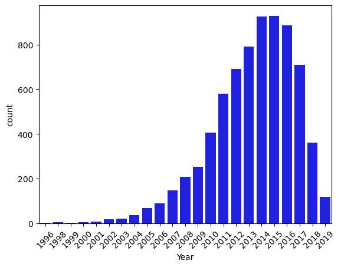

```python
# Univariate analysis for Year

sns.countplot(x = 'Year', data = df, color = 'blue');

plt.xticks(rotation = 45);
```

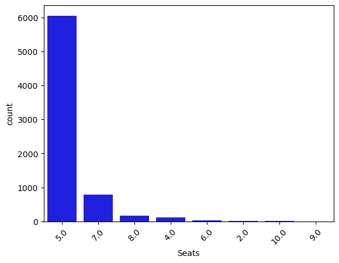

```python
# Univariate analysis for Seats

sns.countplot(x = 'Seats', data = df, color = 'blue', order = df['Seats'].value_counts().index);

plt.xticks(rotation = 45);
```

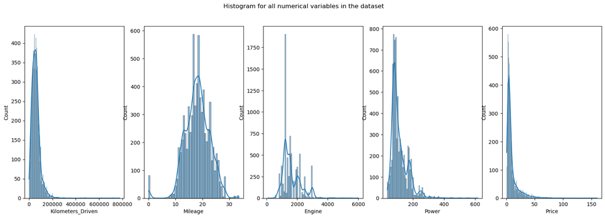

```python
# Univariate analysis for numerical variables

fig, axes = plt.subplots(1, 5, figsize = (20, 6))

fig.suptitle('Histogram for all numerical variables in the dataset')

sns.histplot(x = 'Kilometers_Driven', data = df, kde = True, ax = axes[0]);

sns.histplot(x = 'Mileage', data = df, kde = True, ax = axes[1]);

sns.histplot(x = 'Engine', data = df, kde = True, ax = axes[2]);

sns.histplot(x = 'Power', data = df, kde = True, ax = axes[3]);

sns.histplot(x = 'Price', data = df, kde = True, ax = axes[4]);
```

- KM Driven is right skewed
- Mileage is a multimodal normal distribution
- Engine is right skewed and multimodal
- Power is right skewed and bimodal
- Price is right skewed
- log_transformation needs to be done for dependent variables: KM driven and price since they're right skewed

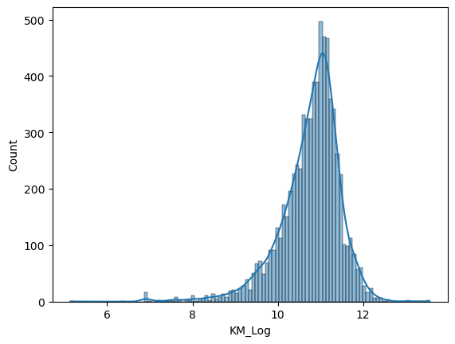

```python
# Log transformation of Kilometers_Driven variable
df['KM_Log'] = np.log(df['Kilometers_Driven'])


# Plotting Engine_New to look at distribution
sns.histplot(data=df, x='KM_Log', kde=True)
```

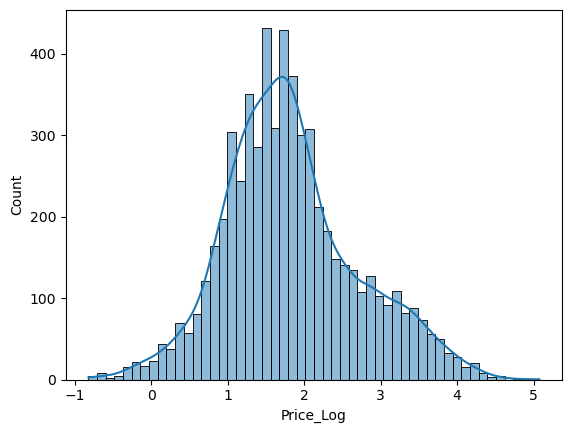

```python
# Log transformation of Price variable
df['Price_Log'] = np.log(df['Price'])

# Plotting Engine_New to look at distribution
sns.histplot(data=df, x='Price_Log', kde=True)
```

```python
# Checking log columns

df.head()
```

|  | S.No. | Name | Location | Year | Kilometers_Driven | Fuel_Type | Transmission | Owner_Type | Mileage | Engine | Power | Seats | New_price | Price | KM_Log | Price_Log |
| --- | --- | --- | --- | --- | --- | --- | --- | --- | --- | --- | --- | --- | --- | --- | --- | --- |
| 0 | 0 | Maruti Wagon R LXI CNG | Mumbai | 2010 | 72000 | CNG | Manual | First | 26.60 | 998.0 | 58.16 | 5.0 | NaN | 1.75 | 11.184421 | 0.559616 |
| 1 | 1 | Hyundai Creta 1.6 CRDi SX Option | Pune | 2015 | 41000 | Diesel | Manual | First | 19.67 | 1582.0 | 126.20 | 5.0 | NaN | 12.50 | 10.621327 | 2.525729 |
| 2 | 2 | Honda Jazz V | Chennai | 2011 | 46000 | Petrol | Manual | First | 18.20 | 1199.0 | 88.70 | 5.0 | 8.61 | 4.50 | 10.736397 | 1.504077 |
| 3 | 3 | Maruti Ertiga VDI | Chennai | 2012 | 87000 | Diesel | Manual | First | 20.77 | 1248.0 | 88.76 | 7.0 | NaN | 6.00 | 11.373663 | 1.791759 |
| 4 | 4 | Audi A4 New 2.0 TDI Multitronic | Coimbatore | 2013 | 40670 | Diesel | Automatic | Second | 15.20 | 1968.0 | 140.80 | 5.0 | NaN | 17.74 | 10.613246 | 2.875822 |

## **Bivariate Analysis**

**Questions:**

1. Plot a scatter plot for the log transformed values(if log_transformation done in previous steps)?
2. What can we infer form the correlation heatmap? Is there correlation between the dependent and independent variables?
3. Plot a box plot for target variable and categorical variable 'Location' and write your observations?

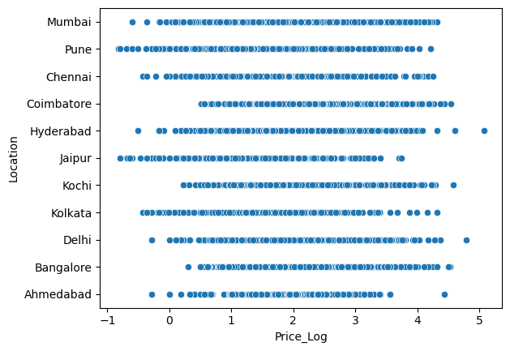

```python
# Scatterplot between price_log and location
sns.scatterplot(x = 'Price_Log', y = 'Location', data = df)
plt.show()
```

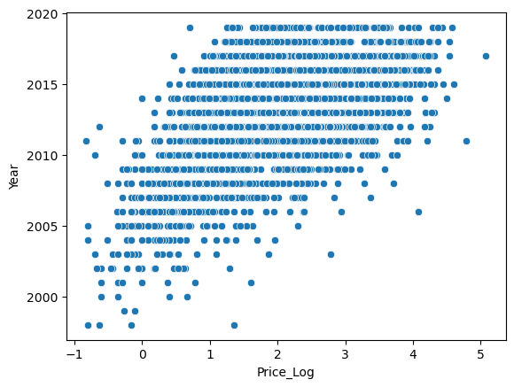

```python
# Scatterplot between price_log and year
sns.scatterplot(x = 'Price_Log', y = 'Year', data = df)
plt.show()
```

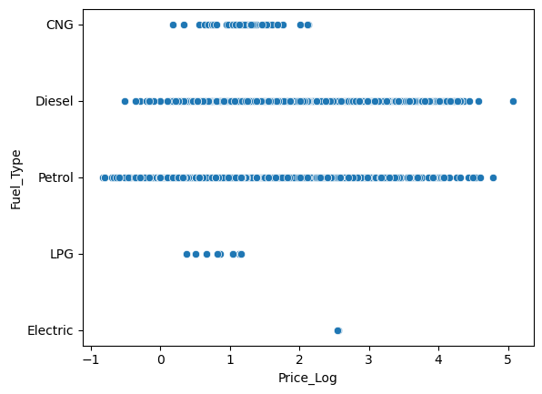

```python
# Scatterplot between price_log and fuel type
sns.scatterplot(x = 'Price_Log', y = 'Fuel_Type', data = df)
plt.show()
```

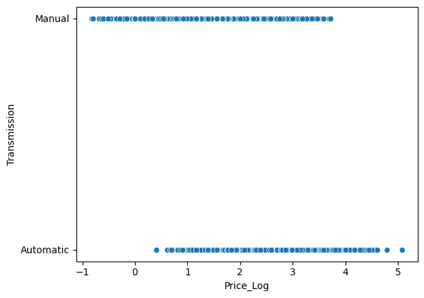

```python
# Scatterplot between price_log and transmission
sns.scatterplot(x = 'Price_Log', y = 'Transmission', data = df)
plt.show()
```

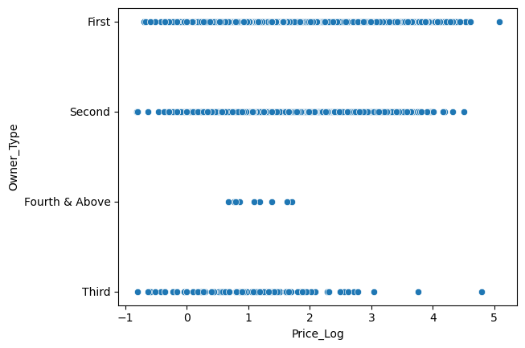

```python
# Scatterplot between price_log and owner
sns.scatterplot(x = 'Price_Log', y = 'Owner_Type', data = df)
plt.show()
```

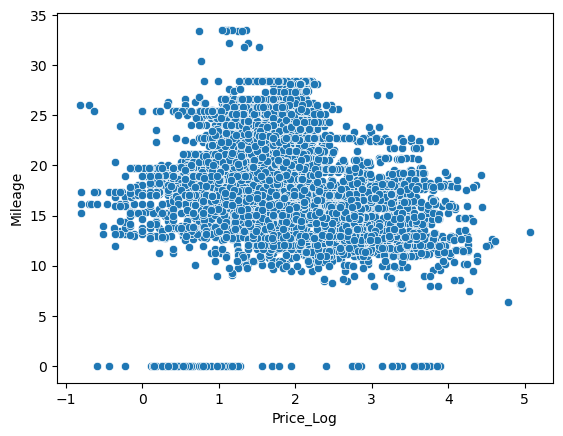

```python
# Scatterplot between price_log and mileage
sns.scatterplot(x = 'Price_Log', y = 'Mileage', data = df)
plt.show()
```

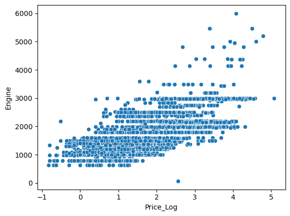

```python
# Scatterplot between price_log and engine
sns.scatterplot(x = 'Price_Log', y = 'Engine', data = df)
plt.show()
```

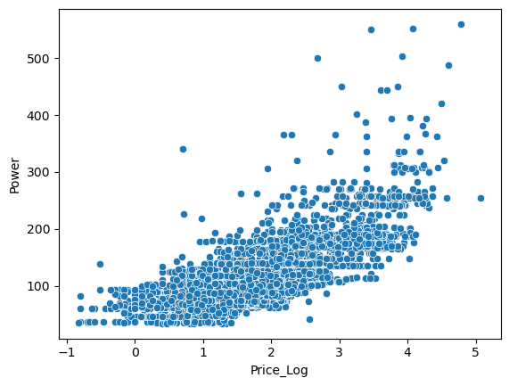

```python
# Scatterplot between price_log and power
sns.scatterplot(x = 'Price_Log', y = 'Power', data = df)
plt.show()
```

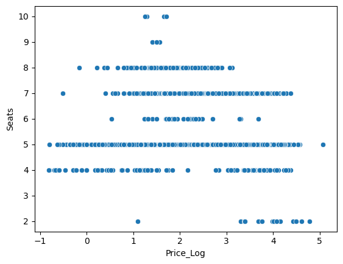

```python
# Scatterplot between price_log and seats
sns.scatterplot(x = 'Price_Log', y = 'Seats', data = df)
plt.show()
```

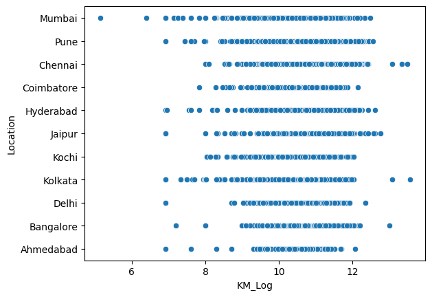

```python
# Scatterplot between kilometers driven log and location
sns.scatterplot(x = 'KM_Log', y = 'Location', data = df)
plt.show()
```

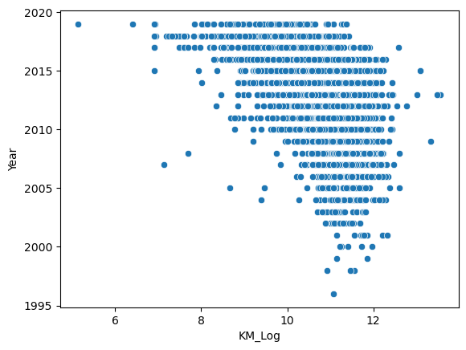

```python
# Scatterplot between kilometers driven log and year
sns.scatterplot(x = 'KM_Log', y = 'Year', data = df)
plt.show()
```

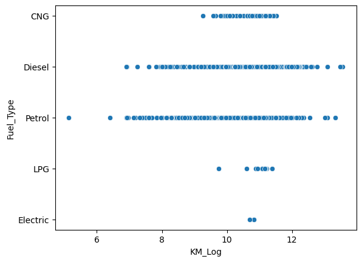

```python
# Scatterplot between kilometers driven log and fuel type
sns.scatterplot(x = 'KM_Log', y = 'Fuel_Type', data = df)
plt.show()
```

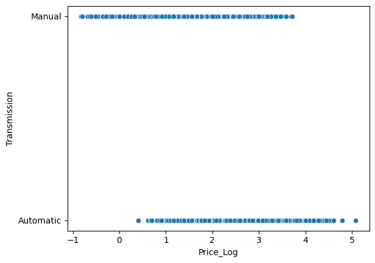

```python
# Scatterplot between kilometers driven log and transmission
sns.scatterplot(x = 'Price_Log', y = 'Transmission', data = df)
plt.show()
```

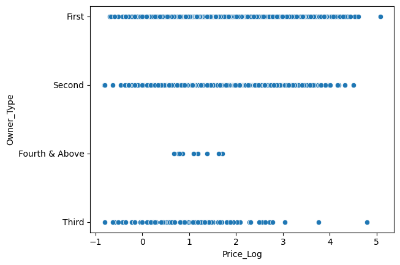

```python
# Scatterplot between kilometers driven log and owner
sns.scatterplot(x = 'Price_Log', y = 'Owner_Type', data = df)
plt.show()
```

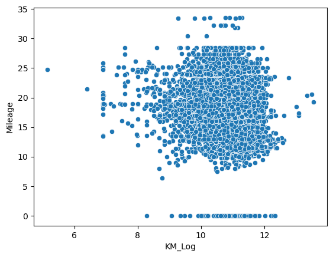

```python
# Scatterplot between kilometers driven log and mileage
sns.scatterplot(x = 'KM_Log', y = 'Mileage', data = df)
plt.show()
```

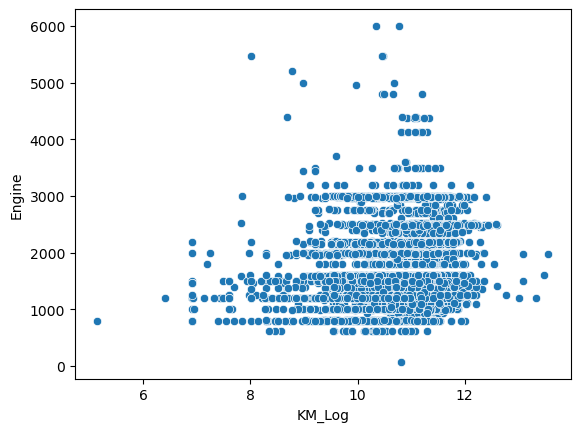

```python
# Scatterplot between kilometers driven log and engine
sns.scatterplot(x = 'KM_Log', y = 'Engine', data = df)
plt.show()
```

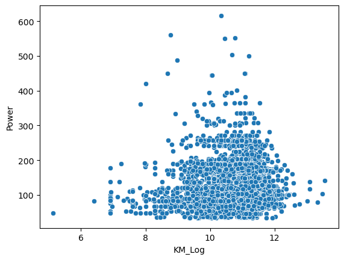

```python
# Scatterplot between kilometers driven log and power
sns.scatterplot(x = 'KM_Log', y = 'Power', data = df)
plt.show()
```

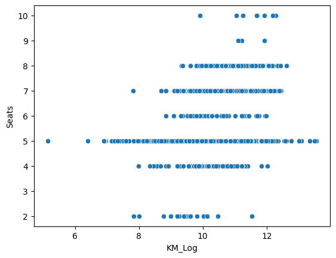

```python
# Scatterplot between kilometers driven log and seats
sns.scatterplot(x = 'KM_Log', y = 'Seats', data = df)
plt.show()
```

### Scatterplot Observations

- Price log
  - Price log and Year has a positive correlation. As the Year of the car increases, the price increases, which mkaes sense since newer cars would have more value.
  - Price log and Engine has a positive correlation. As Engine increases, the price increases.
  - Price log and Power has a positive correlation. As Power increases, the price increases.
  - Price log and Mileage has a lot of clustered data where mileage is between 10 and 30 especially where price log is between 1 and 2
- Kilometers Driven log
  - KM Driven log and Year has a negative correlation. As the year increases, the KM Driven decreases, which makes sense since newer cars are driven less than older cars
  - KM Driven log & Mileage has clustered data where mileage is between 10 and 30 and KM log is between 10 and 12
  - KM Driven log & Engine has clustered data where Engine is between 1000 and 3000 and KM log is between 10 and 12
  - KM Driven log & Power has clustered data where Power is between 50 and 300 and KM log is between 10 and 12

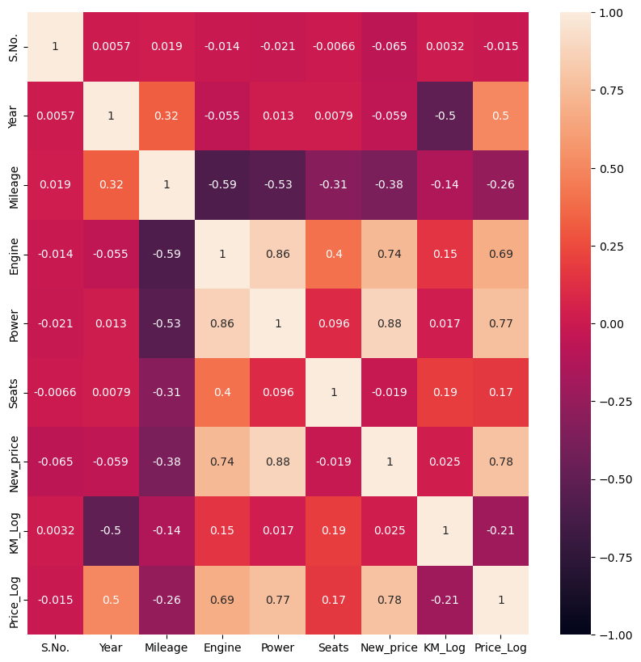

```python
# What can we infer form the correlation heatmap? Is there correlation between the dependent and independent variables?
# Heatmap with only log transformed columns, need to drop original skewed data

plt.figure(figsize = (10, 10))
sns.heatmap(df.drop(['Kilometers_Driven', 'Price'],axis = 1).corr(numeric_only = True), annot = True, vmin = -1, vmax = 1)
plt.show()
```

### Heatmap Observations

#### Strong Correlation Observations (>=0.5 or <=-0.5)

###### Dependent variable correlations

- Positive correlation between Price_Log and Power (0.77)
- Positive correlation between Price_Log and Engine (0.69)
  - The above 2 findings show that power and engine influence the price. It makes sense since the engine is the most important part of the car and power is also a measure of the engine
- Positive correlation between Price_Log and Year (0.5)
  - The price is dependent on the year since the newer a car, the higher the price

###### Independent variable correlations

- Positive correlation between Power and Engine (0.86)
  - Power and Engine are strongly correlated since they're both measures of engine health
- Negative correlation between KM_Log and Year (-0.5)
  - This correlates with the scatterplot findings. The older a car, the more it will have been driven/used
- Negative correlation between Mileage and Engine (-0.59)
- Negative correlation between Mileage and Power (-0.53)
  - The above 2 findings make sense since the more a car is driven or used, the engine health will decline

```python
# Plot a box plot for target variable and categorical variable 'Location' and write your observations?
# This function takes the categorical column as the input and returns the boxplots for the variable.
def boxplot(z):

    plt.figure(figsize = (12, 5)) # Setting size of boxplot

    sns.boxplot(x = z, y = df['Price']) # Defining x and y

    plt.show()

    plt.figure(figsize = (12, 5))

    plt.title('Without Outliers')

    sns.boxplot(x = z, y = df['Price'], showfliers = False) # Turning off the outliers

    plt.show()
```

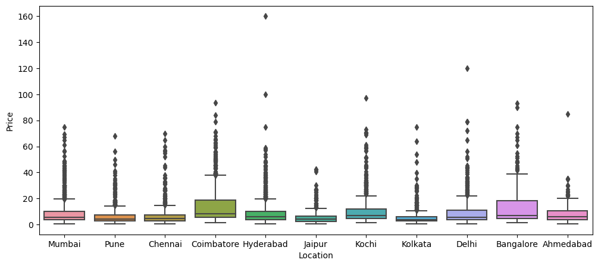

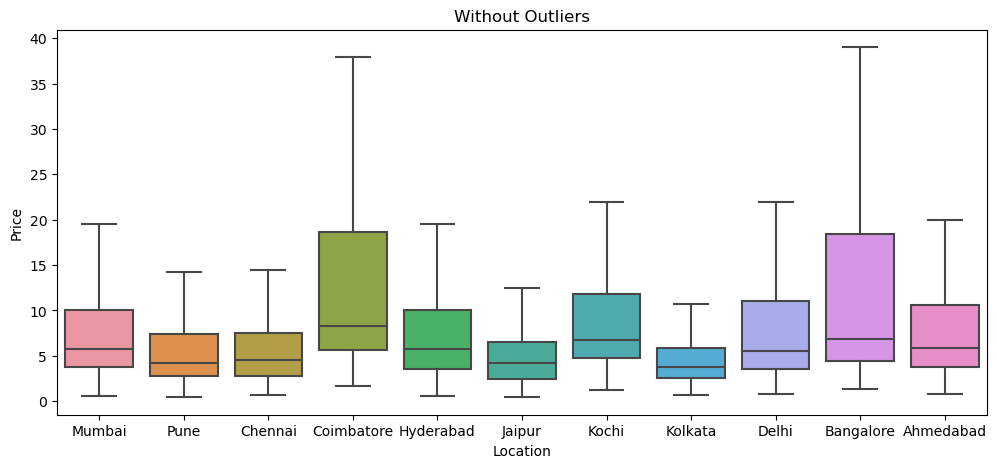

```python
# Box plot for price and location
boxplot(data['Location'])
```

### Boxplot Observations

- The medians are all very similar and right skewed across all locations
- Jaipur has the least amount of skew
- Coimbatore and Bangalore have the highest medians, longer dispersions, and longer upper whiskers than all other locations. The price range seems to vary the most in these locations. It might be good to focus on these locations for car resales.
- There are many outliers outside of the upper limit for all locations

### **Feature Engineering**

**Think about it:** The `Name` column in the current format might not be very useful in our analysis. Since the name contains both the brand name and the model name of the vehicle, the column would have too many unique values to be useful in prediction. Can we extract that information from that column?

- **Hint:** With 2041 unique names, car names are not going to be great predictors of the price in our current data. But we can process this column to extract important information for example brand name.

```python
# Extract Brand from Name
df["Brand"] = data["Name"].apply(lambda x: x.split(" ")[0].lower())
```

```python
# Extract Model from Name
df["Model"] = data["Name"].apply(lambda x: x.split(" ")[1].lower())
```

```python
# Remove Name column
df = df.drop("Name", axis=1)
```

```python
# Check columns for Brand and Model & Name drop
df.head()
```

|  | S.No. | Location | Year | Kilometers_Driven | Fuel_Type | Transmission | Owner_Type | Mileage | Engine | Power | Seats | New_price | Price | KM_Log | Price_Log | Brand | Model |
| --- | --- | --- | --- | --- | --- | --- | --- | --- | --- | --- | --- | --- | --- | --- | --- | --- | --- |
| 0 | 0 | Mumbai | 2010 | 72000 | CNG | Manual | First | 26.60 | 998.0 | 58.16 | 5.0 | NaN | 1.75 | 11.184421 | 0.559616 | maruti | wagon |
| 1 | 1 | Pune | 2015 | 41000 | Diesel | Manual | First | 19.67 | 1582.0 | 126.20 | 5.0 | NaN | 12.50 | 10.621327 | 2.525729 | hyundai | creta |
| 2 | 2 | Chennai | 2011 | 46000 | Petrol | Manual | First | 18.20 | 1199.0 | 88.70 | 5.0 | 8.61 | 4.50 | 10.736397 | 1.504077 | honda | jazz |
| 3 | 3 | Chennai | 2012 | 87000 | Diesel | Manual | First | 20.77 | 1248.0 | 88.76 | 7.0 | NaN | 6.00 | 11.373663 | 1.791759 | maruti | ertiga |
| 4 | 4 | Coimbatore | 2013 | 40670 | Diesel | Automatic | Second | 15.20 | 1968.0 | 140.80 | 5.0 | NaN | 17.74 | 10.613246 | 2.875822 | audi | a4 |

### **Missing value treatment**

```python
# Show rows where null values in Mileage
mileage_missing_data = df[df['Mileage'].isnull()]
print(mileage_missing_data)
```

```
      S.No. Location  Year  Kilometers_Driven Fuel_Type Transmission  \
4446   4446  Chennai  2016              50000  Electric    Automatic
4904   4904   Mumbai  2011              44000  Electric    Automatic

     Owner_Type  Mileage  Engine  Power  Seats  New_price  Price     KM_Log  \
4446      First      NaN    72.0   41.0    5.0      13.58  13.00  10.819778
4904      First      NaN  1798.0   73.0    5.0        NaN  12.75  10.691945

      Price_Log     Brand  Model
4446   2.564949  mahindra      e
4904   2.545531    toyota  prius
```

```python
# impute Mileage and fill with median value
df['Mileage'] = (df['Mileage'].fillna(df['Mileage'].median))
```

```python
# Check if null values in Mileage
mileage_missing_data = df[df['Mileage'].isnull()]
print(mileage_missing_data)
```

```
Empty DataFrame
Columns: [S.No., Location, Year, Kilometers_Driven, Fuel_Type, Transmission, Owner_Type, Mileage, Engine, Power, Seats, New_price, Price, KM_Log, Price_Log, Brand, Model]
Index: []
```

```python
# Show rows where null values in Seats
seats_missing_data = df[df['Seats'].isnull()]
print(seats_missing_data)
```

```
      S.No.    Location  Year  Kilometers_Driven Fuel_Type Transmission  \
194     194   Ahmedabad  2007              60006    Petrol       Manual
208     208     Kolkata  2010              42001    Petrol       Manual
229     229   Bangalore  2015              70436    Diesel       Manual
733     733     Chennai  2006              97800    Petrol       Manual
749     749      Mumbai  2008              55001    Diesel    Automatic
1294   1294       Delhi  2009              55005    Petrol       Manual
1327   1327   Hyderabad  2015              50295    Petrol       Manual
1385   1385        Pune  2004             115000    Petrol       Manual
1460   1460  Coimbatore  2008              69078    Petrol       Manual
1917   1917      Jaipur  2005              88000    Petrol       Manual
2074   2074        Pune  2011              24255    Petrol       Manual
2096   2096  Coimbatore  2004              52146    Petrol       Manual
2264   2264        Pune  2012              24500    Petrol       Manual
2325   2325        Pune  2015              67000    Petrol       Manual
```

[output cut: 149 more lines]

```python
# impute Seats and fill with median value
df['Seats'] = (df['Seats'].fillna(df['Seats'].median))
```

```python
# check if null values in seats
seats_missing_data = df[df['Seats'].isnull()]
print(seats_missing_data)
```

```
Empty DataFrame
Columns: [S.No., Location, Year, Kilometers_Driven, Fuel_Type, Transmission, Owner_Type, Mileage, Engine, Power, Seats, New_price, Price, KM_Log, Price_Log, Brand, Model]
Index: []
```

```python
# Show rows where null values in Engine
engine_missing_data = df[df['Engine'].isnull()]
print(engine_missing_data)
```

```
      S.No.    Location  Year  Kilometers_Driven Fuel_Type Transmission  \
194     194   Ahmedabad  2007              60006    Petrol       Manual
208     208     Kolkata  2010              42001    Petrol       Manual
733     733     Chennai  2006              97800    Petrol       Manual
749     749      Mumbai  2008              55001    Diesel    Automatic
1294   1294       Delhi  2009              55005    Petrol       Manual
1327   1327   Hyderabad  2015              50295    Petrol       Manual
1385   1385        Pune  2004             115000    Petrol       Manual
1460   1460  Coimbatore  2008              69078    Petrol       Manual
2074   2074        Pune  2011              24255    Petrol       Manual
2096   2096  Coimbatore  2004              52146    Petrol       Manual
2264   2264        Pune  2012              24500    Petrol       Manual
2325   2325        Pune  2015              67000    Petrol       Manual
2335   2335      Mumbai  2007              55000    Petrol       Manual
2530   2530       Kochi  2014              64158    Diesel    Automatic
```

[output cut: 176 more lines]

```python
# impute Engine and fill with mean value
df['Engine'] = (df['Engine'].fillna(df['Engine'].mean))
```

```python
# check if null values in engine
engine_missing_data = df[df['Engine'].isnull()]
print(engine_missing_data)
```

```
Empty DataFrame
Columns: [S.No., Location, Year, Kilometers_Driven, Fuel_Type, Transmission, Owner_Type, Mileage, Engine, Power, Seats, New_price, Price, KM_Log, Price_Log, Brand, Model]
Index: []
```

```python
# Show rows where null values in Power
power_missing_data = df[df['Power'].isnull()]
print(power_missing_data)
```

```
      S.No.    Location  Year  Kilometers_Driven Fuel_Type Transmission  \
76       76      Jaipur  2008             111111    Diesel       Manual
79       79   Hyderabad  2005              87591    Petrol       Manual
89       89   Hyderabad  2007              73745    Petrol       Manual
120     120      Mumbai  2005             102000    Petrol       Manual
143     143       Kochi  2008              80759    Petrol       Manual
...     ...         ...   ...                ...       ...          ...
6896   6896   Hyderabad  2013              86000    Diesel       Manual
6902   6902       Kochi  2012              59311    Petrol       Manual
6947   6947       Delhi  2012              77800    Petrol       Manual
7092   7092  Coimbatore  2007              64168    Petrol    Automatic
7145   7145     Kolkata  2012              37212    Petrol       Manual

     Owner_Type Mileage                                             Engine  \
76        First    17.8                                             1399.0
```

[output cut: 38 more lines]

```python
# impute Power and fill with mean value
df['Power'] = (df['Power'].fillna(df['Power'].mean))
```

```python
# check if null values in power
power_missing_data = df[df['Power'].isnull()]
print(power_missing_data)
```

```
Empty DataFrame
Columns: [S.No., Location, Year, Kilometers_Driven, Fuel_Type, Transmission, Owner_Type, Mileage, Engine, Power, Seats, New_price, Price, KM_Log, Price_Log, Brand, Model]
Index: []
```

```python
# Remove New_price column
df = df.drop("New_price", axis=1)
```

```python
# Check if New_price was dropped
df.head()
```

|  | S.No. | Location | Year | Kilometers_Driven | Fuel_Type | Transmission | Owner_Type | Mileage | Engine | Power | Seats | Price | KM_Log | Price_Log | Brand | Model |
| --- | --- | --- | --- | --- | --- | --- | --- | --- | --- | --- | --- | --- | --- | --- | --- | --- |
| 0 | 0 | Mumbai | 2010 | 72000 | CNG | Manual | First | 26.6 | 998.0 | 58.16 | 5.0 | 1.75 | 11.184421 | 0.559616 | maruti | wagon |
| 1 | 1 | Pune | 2015 | 41000 | Diesel | Manual | First | 19.67 | 1582.0 | 126.2 | 5.0 | 12.50 | 10.621327 | 2.525729 | hyundai | creta |
| 2 | 2 | Chennai | 2011 | 46000 | Petrol | Manual | First | 18.2 | 1199.0 | 88.7 | 5.0 | 4.50 | 10.736397 | 1.504077 | honda | jazz |
| 3 | 3 | Chennai | 2012 | 87000 | Diesel | Manual | First | 20.77 | 1248.0 | 88.76 | 7.0 | 6.00 | 11.373663 | 1.791759 | maruti | ertiga |
| 4 | 4 | Coimbatore | 2013 | 40670 | Diesel | Automatic | Second | 15.2 | 1968.0 | 140.8 | 5.0 | 17.74 | 10.613246 | 2.875822 | audi | a4 |

```python
# Show rows where null values in Price
price_missing_data = df[df['Price'].isnull()]
print(price_missing_data)
```

```
      S.No.    Location  Year  Kilometers_Driven Fuel_Type Transmission  \
6019   6019       Delhi  2014              40929       CNG       Manual
6020   6020  Coimbatore  2013              54493    Petrol       Manual
6021   6021      Mumbai  2017              34000    Diesel       Manual
6022   6022   Hyderabad  2012             139000    Diesel       Manual
6023   6023      Mumbai  2014              29000    Petrol       Manual
...     ...         ...   ...                ...       ...          ...
7248   7248   Hyderabad  2011              89411    Diesel       Manual
7249   7249      Mumbai  2015              59000    Petrol    Automatic
7250   7250     Kolkata  2012              28000    Diesel       Manual
7251   7251        Pune  2013              52262    Petrol    Automatic
7252   7252       Kochi  2014              72443    Diesel    Automatic

     Owner_Type Mileage  Engine  \
6019      First   32.26   998.0
```

[output cut: 38 more lines]

```python
# Remove rows where price is null
df = df.dropna()
```

```python
# Check if rows where price is null were removed
df.info()
```

```
<class 'pandas.core.frame.DataFrame'>
Index: 6018 entries, 0 to 6018
Data columns (total 16 columns):
 #   Column             Non-Null Count  Dtype
---  ------             --------------  -----
 0   S.No.              6018 non-null   int64
 1   Location           6018 non-null   object
 2   Year               6018 non-null   int64
 3   Kilometers_Driven  6018 non-null   int64
 4   Fuel_Type          6018 non-null   object
 5   Transmission       6018 non-null   object
 6   Owner_Type         6018 non-null   object
 7   Mileage            6018 non-null   object
 8   Engine             6018 non-null   object
 9   Power              6018 non-null   object
 10  Seats              6018 non-null   object
 11  Price              6018 non-null   float64
 12  KM_Log             6018 non-null   float64
 13  Price_Log          6018 non-null   float64
 14  Brand              6018 non-null   object
 15  Model              6018 non-null   object
dtypes: float64(3), int64(3), object(10)
memory usage: 799.3+ KB
```

## **Building Various Models**

1. What we want to predict is the "Price". We will use the normalized version 'price_log' for modeling.
2. Before we proceed to the model, we'll have to encode categorical features. We will drop categorical features like Name.
3. We'll split the data into train and test, to be able to evaluate the model that we build on the train data.
4. Build Regression models using train data.
5. Evaluate the model performance.

### **Split the Data**

Step1: Seperating the indepdent variables (X) and the dependent variable (y).

Step2: Encode the categorical variables in X using pd.dummies.

Step3: Split the data into train and test using train_test_split.

**Question:**

1. Why we should drop 'Name','Price','price_log','Kilometers_Driven' from X before splitting?
- I already dropped Name since it is not useful and I already split it into two useful columns: Brand and Model
- Price and price_log are dropped since they're the target variable
- Kilometers Driven is dropped because we want to only use the log transformation of Kilometers Driven: KM_Log

```python
# Split Dataset
X = df.drop(['Price','Price_Log','Kilometers_Driven', 'Mileage', 'Engine', 'Power'], axis = 1)
y = df[["Price", "Price_Log"]]

# Get dummies
X = pd.get_dummies(X, drop_first = True)

# Split data into training and test set:
X_train, X_test, y_train, y_test = train_test_split(X, y, test_size = .3, random_state = 0)
```

```python
print(X.info())
```

```
<class 'pandas.core.frame.DataFrame'>
Index: 6018 entries, 0 to 6018
Columns: 268 entries, S.No. to Model_zest
dtypes: bool(265), float64(1), int64(2)
memory usage: 1.7 MB
None
```

```python
# Let us write a function for calculating r2_score and RMSE on train and test data
# This function takes model as an input on which we have trained particular algorithm
# The categorical column as the input and returns the boxplots and histograms for the variable

def get_model_score(model, flag = True):
    '''
    model : regressor to predict values of X

    '''
    # Defining an empty list to store train and test results
    score_list = []

    pred_train = model.predict(X_train)

    pred_train_ = np.exp(pred_train)

    pred_test = model.predict(X_test)

    pred_test_ = np.exp(pred_test)

    train_r2 = metrics.r2_score(y_train['Price'], pred_train_)

    test_r2 = metrics.r2_score(y_test['Price'], pred_test_)

    train_rmse = metrics.mean_squared_error(y_train['Price'], pred_train_, squared = False)

    test_rmse = metrics.mean_squared_error(y_test['Price'], pred_test_, squared = False)

    # Adding all scores in the list
    score_list.extend((train_r2, test_r2, train_rmse, test_rmse))

    # If the flag is set to True then only the following print statements will be dispayed, the default value is True
    if flag == True:

        print("R-square on training set : ", metrics.r2_score(y_train['Price'], pred_train_))

        print("R-square on test set : ", metrics.r2_score(y_test['Price'], pred_test_))

        print("RMSE on training set : ", np.sqrt(metrics.mean_squared_error(y_train['Price'], pred_train_)))

        print("RMSE on test set : ", np.sqrt(metrics.mean_squared_error(y_test['Price'], pred_test_)))

    # Returning the list with train and test scores
    return score_list
```

For Regression Problems, some of the algorithms used are :

**1) Linear Regression**  
**2) Ridge / Lasso Regression**  
**3) Decision Trees**  
**4) Random Forest**

### Linear Regression Model

```python
# Create a linear regression model
lr = LinearRegression()
```

```python
# Fit linear regression model
lr.fit(X_train, y_train['Price_Log'])
```

```
LinearRegression()
```

```python
# Get score of the model
lr_score = get_model_score(lr)
```

```
R-square on training set :  0.9211776574576269
R-square on test set :  0.8675633590328681
RMSE on training set :  3.0964980974157146
RMSE on test set :  4.175470208542416
```

### LR Observations

- R-square on training set is 92.1% which shows a strong fit
- R-square on test set is 86.8% which is also strong but lower than R-square on training set
- RMSE for test set is slightly higher than the training error but the numbers are pretty close. This shows that the model performs a little worse on the test data but the difference is not that large
- Improvements can definitely be made

### OLS Model

```python
X_train1 = X_train.astype(float)
y_train1 = y_train.astype(float)

# Import Statsmodels
import statsmodels.api as sm

# Statsmodel api does not add a constant by default. We need to add it explicitly
x_train = sm.add_constant(X_train1)

# Add constant to test data
x_test = sm.add_constant(X_test)

def build_ols_model(train):

    # Create the model
    olsmodel = sm.OLS(y_train1["Price_Log"], X_train1)

    return olsmodel.fit()


# Fit linear model on new dataset
olsmodel1 = build_ols_model(X_train1)

print(olsmodel1.summary())
```

```
                            OLS Regression Results
==============================================================================
Dep. Variable:              Price_Log   R-squared:                       0.962
Model:                            OLS   Adj. R-squared:                  0.959
Method:                 Least Squares   F-statistic:                     432.9
Date:                Tue, 04 Mar 2025   Prob (F-statistic):               0.00
Time:                        01:17:50   Log-Likelihood:                 1450.2
No. Observations:                4212   AIC:                            -2438.
Df Residuals:                    3981   BIC:                            -972.6
Df Model:                         230
Covariance Type:            nonrobust
============================================================================================================================================================================================================================================================================================================…
                                                                                                                                                                                                                                                            coef    std err          t      P>|t|      [0.02…
------------------------------------------------------------------------------------------------------------------------------------------------------------------------------------------------------------------------------------------------------------------------------------------------------------…
S.No.                                                                                                                                                                                                                                                 -1.087e-06    1.6e-06     -0.678      0.498   -4.23e-0…
Year                                                                                                                                                                                                                                                      0.1104      0.001     79.858      0.000       0.10…
KM_Log                                                                                                                                                                                                                                                   -0.0701      0.005    -12.876      0.000      -0.08…
Location_Bangalore                                                                                                                                                                                                                                        0.1913      0.018     10.467      0.000       0.15…
Location_Chennai                                                                                                                                                                                                                                          0.0809      0.017      4.662      0.000       0.04…
Location_Coimbatore                                                                                                                                                                                                                                       0.1418      0.017      8.375      0.000       0.10…
Location_Delhi                                                                                                                                                                                                                                           -0.0862      0.017     -5.107      0.000      -0.11…
Location_Hyderabad                                                                                                                                                                                                                                        0.1489      0.016      9.117      0.000       0.11…
Location_Jaipur                                                                                                                                                                                                                                          -0.0289      0.018     -1.622      0.105      -0.06…
Location_Kochi                                                                                                                                                                                                                                           -0.0187      0.017     -1.117      0.264      -0.05…
Location_Kolkata                                                                                                                                                                                                                                         -0.2177      0.017    -12.675      0.000      -0.25…
Location_Mumbai                                                                                                                                                                                                                                          -0.0608      0.016     -3.718      0.000      -0.09…
```

[output cut: 278 more lines]

### OLS Observations

```python
# Retrive Coeff values, p-values and store them in the dataframe
olsmod = pd.DataFrame(olsmodel1.params, columns = ['coef'])

olsmod['pval'] = olsmodel1.pvalues
```

```python
# Filter by significant p-value (pval <= 0.05) and sort descending by Odds ratio

olsmod = olsmod.sort_values(by = "pval", ascending = False)

pval_filter = olsmod['pval']<= 0.05

olsmod[pval_filter]
```

|  | coef | pval |
| --- | --- | --- |
| Model_petra | -1.598950e-16 | 0.020275 |
| Seats_4.0 | 9.766476e-02 | 0.016083 |
| Fuel_Type_Diesel | 7.862642e-02 | 0.014901 |
| Model_redi | -2.036638e-16 | 0.006465 |
| Model_x3 | 4.482975e-01 | 0.001560 |
| ... | ... | ... |
| Model_crosspolo | -2.493191e+01 | 0.000000 |
| Model_cruze | -2.164502e+01 | 0.000000 |
| Model_d-max | -7.336627e+01 | 0.000000 |
| Model_duster | -2.423209e+01 | 0.000000 |
| Model_zest | -1.424213e+01 | 0.000000 |

250 rows × 2 columns

- Even if pval <= 0.05, if the coefficient is low, the variable probably isn't statistically significant, like Model_petra
- However, variables like Seats_4.0, Fuel_Type_Diesel, and Model_x3 have an effect on price

```python
# We are looking are overall significant varaible

pval_filter = olsmod['pval']<= 0.05
imp_vars = olsmod[pval_filter].index.tolist()

# We are going to get overall varaibles (un-one-hot encoded varables) from categorical varaibles
sig_var = []
for col in imp_vars:
    if '' in col:
        first_part = col.split('_')[0]
        for c in df.columns:
            if first_part in c and c not in sig_var :
                sig_var.append(c)


start = '\033[1m'
end = '\033[95m'
print(start+ 'Most overall significant categorical varaibles of LINEAR REGRESSION  are ' +end,':\n', sig_var)
```

```
Most overall significant categorical varaibles of LINEAR REGRESSION  are  :
 ['Model', 'Seats', 'Fuel_Type', 'Location', 'Owner_Type', 'KM_Log', 'Transmission', 'Brand', 'Year']
```

### Ridge/Lasso Regression

```python
# Import Ridge/ Lasso Regression from sklearn
from sklearn.linear_model import Ridge, Lasso
```

```python
# Create a Ridge regression model
ridge = Ridge(alpha=1.0)
```

```python
# Fit Ridge regression model
ridge.fit(X_train,y_train['Price_Log'])
```

```
Ridge()
```

```python
# Get score of the model
ridge_score = get_model_score(ridge)
```

```
R-square on training set :  0.9024402056469364
R-square on test set :  0.8832391879550567
RMSE on training set :  3.444939401200839
RMSE on test set :  3.920575884458006
```

### Ridge Model Observations

- R-square on training set is 90.2% which is good
- Test score is 88.3% which is also good and similar to train score
- RMSE on training set is 3.44
- RMSE on test set is similar to training set around 3.92
- The test error is slightly higher than training but they are very close
- Ridge model has minimal overfitting and better generalization than OLS and LR models

```python
#create lasso regression model
lasso=Lasso(alpha=1.0)
```

```python
#Fit Lasso regression model
lasso.fit(X_train,y_train['Price_Log'])
```

```
Lasso()
```

```python
# Get score of the model
lasso_score = get_model_score(lasso)
```

```
R-square on training set :  -0.039340035034471255
R-square on test set :  -0.04808215581306685
RMSE on training set :  11.244107186022896
RMSE on test set :  11.74624281818039
```

### Lasso Observations

- Results are very poor compared to LR, OLS, or Ridge models
- Underfitting issue

### Decision Tree

```python
# Import Decision tree for Regression from sklearn
from sklearn.tree import DecisionTreeRegressor
```

```python
# Create a decision tree regression model, use random_state = 1
dtree = DecisionTreeRegressor(random_state = 1)
```

```python
# Fit decision tree regression model
dtree.fit(X_train, y_train['Price_Log'])
```

```
DecisionTreeRegressor(random_state=1)
```

```python
# Get score of the model
Dtree_model = get_model_score(dtree)
```

```
R-square on training set :  1.0
R-square on test set :  0.7092238564171407
RMSE on training set :  2.6147264698081585e-15
RMSE on test set :  6.187008277719647
```

### Decision Tree Observations:

- R-square on training set is 100% which is perfect
- R-square on testing set is 70.9% which is less than training set
- The R-square results on both training and test confirms that there is an overfitting issue
- RMSE on training set is very close to 0, means it's not generalizing well
- RMSE on test set is 6.19 which is significantly higher than training set, confirming overfitting
- Random forest may have better performance

```python
#Feature Importance
print(pd.DataFrame(dtree.feature_importances_, columns = ["Imp"], index = X_train.columns).sort_values(by = 'Imp', ascending = False))
```

```
                          Imp
Transmission_Manual  0.377529
Year                 0.209727
Fuel_Type_Petrol     0.081204
Seats_7.0            0.026959
Brand_toyota         0.026039
...                       ...
Model_teana          0.000000
Model_fabia          0.000000
Model_thar           0.000000
Model_prius          0.000000
Model_fluence        0.000000

[268 rows x 1 columns]
```

- Transmission Manual is the most important feature, followed by Year, and Fuel Type Petrol
- The rest have almost no importance

### Random Forest

```python
# Import Randomforest for Regression from sklearn
from sklearn.ensemble import RandomForestRegressor
```

```python
# Create a Randomforest regression model
clf = RandomForestRegressor(n_estimators=100)
```

```python
# Fit Randomforest regression model
clf.fit(X_train, y_train['Price_Log'])
```

```
RandomForestRegressor()
```

```python
# Get score of the model
clf_model = get_model_score(clf)
```

```
R-square on training set :  0.9502087311145266
R-square on test set :  0.78415612825245
RMSE on training set :  2.4610630820343897
RMSE on test set :  5.330539577427196
```

### Random Forest Observations

- R-square on training set is 95% which is good
- R-square on testing set is 78.4% which is a pretty big difference from training
- RMSE on training set is 2.46
- RMSE on test set is 5.33
- The test RMSE is higher than training which may suggest overfitting
- Random Forest is performing better than Decision Tree
- Tuning this model should get better results.

```python
# Feature Importance
print(pd.DataFrame(clf.feature_importances_, columns = ["Imp"], index = X_train.columns).sort_values(by = 'Imp', ascending = False))
```

```
                          Imp
Transmission_Manual  0.376012
Year                 0.211626
Fuel_Type_Petrol     0.054899
Fuel_Type_Diesel     0.045376
Seats_7.0            0.026643
...                       ...
Model_platinum       0.000000
Model_fusion         0.000000
Model_e              0.000000
Model_versa          0.000000
Model_sl-class       0.000000

[268 rows x 1 columns]
```

- Most important features are Transmission Manual and Year
- Fuel Type petrol and diesel have impact on price but much less impact than Transmission Manual and Year
- Similar important features to Decision Tree

### **Hyperparameter Tuning: Decision Tree**

```python
#importing required libraries
from sklearn.tree import DecisionTreeClassifier
from sklearn.model_selection import GridSearchCV
from sklearn.metrics import recall_score, make_scorer

# Choose the type of estimator
dtree_tuned = DecisionTreeRegressor(random_state = 1)

# Grid of parameters to choose from
# Check documentation for all the parametrs that the model takes and play with those
parameters = { 'splitter':["best","random"],
    'max_depth': [1, 3, 5, 7, 9, 11, 12, 15],
    'min_samples_leaf': [5, 10, 20, 25]
    }

# Type of scoring used to compare parameter combinations
scorer = 'neg_mean_squared_error'

# Run the grid search
grid_obj = GridSearchCV(estimator=dtree_tuned,param_grid=parameters,
                        cv=10, verbose=1, scoring = scorer)
grid_obj = grid_obj.fit(X_train,y_train)

# Set the model to the best combination of parameters
dtree_tuned = grid_obj.best_estimator_

# Fit the best algorithm to the data
dtree_tuned.fit(X_train,y_train['Price_Log'])
```

```
Fitting 10 folds for each of 64 candidates, totalling 640 fits
```

```
DecisionTreeRegressor(max_depth=15, min_samples_leaf=5, random_state=1,
                      splitter='random')
```

```python
# Get score of the dtree_tuned
Dtree_model_tuned = get_model_score(dtree_tuned)
```

```
R-square on training set :  0.8090229284621688
R-square on test set :  0.6947056164131677
RMSE on training set :  4.8198859670522936
RMSE on test set :  6.339583381036722
```

### Hyperparameter Tuning: Decision Tree Observations

- R-square on training set is 0.809 which is lower than the original model that was overfitting
- R-sqaure on test set however is 0.695 which is similar to original model (0.709). Tuning did not significantly improve performance but helped with overfitting
- RMSE on training is much higher than before
- RMSE on test is similar to before
- Random Forest still performs better than tuned decision tree model

**Feature Importance**

```python
# Feature Importance
print(pd.DataFrame(dtree_tuned.feature_importances_, columns = ["Imp"], index = X_train.columns).sort_values(by = 'Imp', ascending = False))
```

```
                          Imp
Transmission_Manual  0.418326
Year                 0.178855
Fuel_Type_Petrol     0.086998
Fuel_Type_Diesel     0.066636
Seats_7.0            0.025650
...                       ...
Model_enjoy          0.000000
Model_esteem         0.000000
Model_estilo         0.000000
Model_etios          0.000000
Model_zest           0.000000

[268 rows x 1 columns]
```

- Important features are Transmission Manual, Year , Fuel_Type_Petrol, and Fuel_Type Diesel

### **Hyperparameter Tuning: Random Forest**

```python
# Choose the type of Regressor
randomforest_tuned = RandomForestRegressor(random_state=1)

# Define the parameters for Grid to choose from
# Check documentation for all the parametrs that the model takes and play with those
parameters={'max_depth': [1, 2, 3, 5, 7, 9, 10, 11, 12],
    'min_samples_leaf': [5, 10, 20, 25]
  }

# Type of scoring used to compare parameter combinations
scorer = 'neg_mean_squared_error'
# Run the grid search
grid_obj = GridSearchCV(estimator=randomforest_tuned,param_grid=parameters,
                        cv=10, verbose=1, scoring = scorer)
grid_obj = grid_obj.fit(X_train,y_train)

# Set the model to the best combination of parameters
randomforest_tuned=grid_obj.best_estimator_

# Fit the best algorithm to the data
randomforest_tuned.fit(X_train,y_train['Price_Log'])
```

```
Fitting 10 folds for each of 36 candidates, totalling 360 fits
```

```
RandomForestRegressor(max_depth=12, min_samples_leaf=5, random_state=1)
```

```python
# Get score of the model
randomforest_tuned_model = get_model_score(randomforest_tuned)
```

```
R-square on training set :  0.7810125277621676
R-square on test set :  0.6882511238122324
RMSE on training set :  5.161260554260666
RMSE on test set :  6.406248176999117
```

### Hyperparameter Tuning: Random Forest Observations

- R-square on training set is 0.781 which is lower than original model (0.95). Tuning helped with overfitting
- R-square on test set is 0.69 which is lower than original model
- RMSE on training is 5.16 which is higher than original
- RMSE on test is 6.41 which is a little worse than original
- Tuning helped with overfitting

**Feature Importance**

```python
# Feature importance
print(pd.DataFrame(randomforest_tuned.feature_importances_, columns = ["Imp"], index = X_train.columns).sort_values(by = 'Imp', ascending = False))
```

```
                          Imp
Transmission_Manual  0.420919
Year                 0.234463
Fuel_Type_Diesel     0.058153
Fuel_Type_Petrol     0.052889
Seats_7.0            0.029144
...                       ...
Model_mobilio        0.000000
Model_montero        0.000000
Model_mustang        0.000000
Model_mux            0.000000
Model_fluence        0.000000

[268 rows x 1 columns]
```

- Important variables are same as original model

## **Conclusions and Recommendations**

**1. Comparison of various techniques and their relative performance based on chosen Metric (Measure of success):**

- How do different techniques perform? Which one is performing relatively better? Is there scope to improve the performance further?

```python
# Defining list of models you have trained
models = [lr, olsmodel1, ridge, lasso, dtree, clf, dtree_tuned, randomforest_tuned]

# Defining empty lists to add train and test results
r2_train = []
r2_test = []
rmse_train = []
rmse_test = []

# Looping through all the models to get the rmse and r2 scores
for model in models:

    # Accuracy score
    j = get_model_score(model, False)

    r2_train.append(j[0])

    r2_test.append(j[1])

    rmse_train.append(j[2])

    rmse_test.append(j[3])
```

```python
comparison_frame = pd.DataFrame({'Model':['Linear Regression', 'OLS model','Ridge','Lasso','Decision Tree','Random forest','Tuned Decision Tree','Tuned Random forest'],
                                          'Train_r2': r2_train,'Test_r2': r2_test,
                                          'Train_RMSE': rmse_train,'Test_RMSE': rmse_test})
comparison_frame
```

[output not shown]

**2. Refined insights:**

- What are the most meaningful insights relevant to the problem?
- Ridge regression and linear regression had the best performance
- The top 7 locations make up ~75% so maybe there should be a focus on these locations
- Fuel Type of cars are mainly Diesel and Petrol so there's no need to source used cars that don't use these fuel types
- If Owner Type is not first, it seems less likely to sell
- Majority of used cars are 2011 and newer (~70%) but not too new. 2018 and 2019 were much lower. This should be kept in mind. Maybe cars that are 10+ years old should be avoided.
- 84% percent of the cars have 5 seats. There should be a focus on cars that have 5 seats.
- Coimbatore and Bangalore seem to be expensive areas
- Price and Year seem to have a strong correlation

**3. Proposal for the final solution design:**

- What model do you propose to be adopted? Why is this the best solution to adopt?

The ridge regression should be adopted because it had minimal overfitting compared to all of the other models and better generalization. Also, if more features are added to the data sets, ridge model would handle it better than linear regression.